# AnalyticsEdge Wk3 Logistic Regr Notes

### Useful notes to keep in mind from this week’s lectures (and last week’s assignment?)

```r
quality = read.csv("quality.csv")
library(caTools)
split = sample.split(quality$PoorCare, SplitRatio = 0.75)
```

In the above code chunk, sample.split() from the caTools package returns a logical vector with 75% TRUE values and 25% FALSE values. The Proportion of TRUE values for quality$PoorCare at indices of the ‘quality’ dataframe for which ‘split’ is TRUE is the same as that at indices in the ‘quality’ dataframe for which ‘split’ is false. So ‘split’ can be used to construct training and test datasets that have the same distributions of values for quality$PoorCare, which is our response variable of interest.

```r
qualityTrain = subset(quality, split == TRUE)
qualityTest = subset(quality, split == FALSE)
QualityLog = glm(PoorCare ~ OfficeVisits + Narcotics, data=qualityTrain, family=binomial)
predictTrain = predict(QualityLog, type="response")
```

Below we’ll show how to use the ROCR package to both make an ROC (Receiver Operating Characteristics) curve with the threshold values highlighted on the graph and to calculate the AUC (Area Under Curve).

```r
library(ROCR)
```

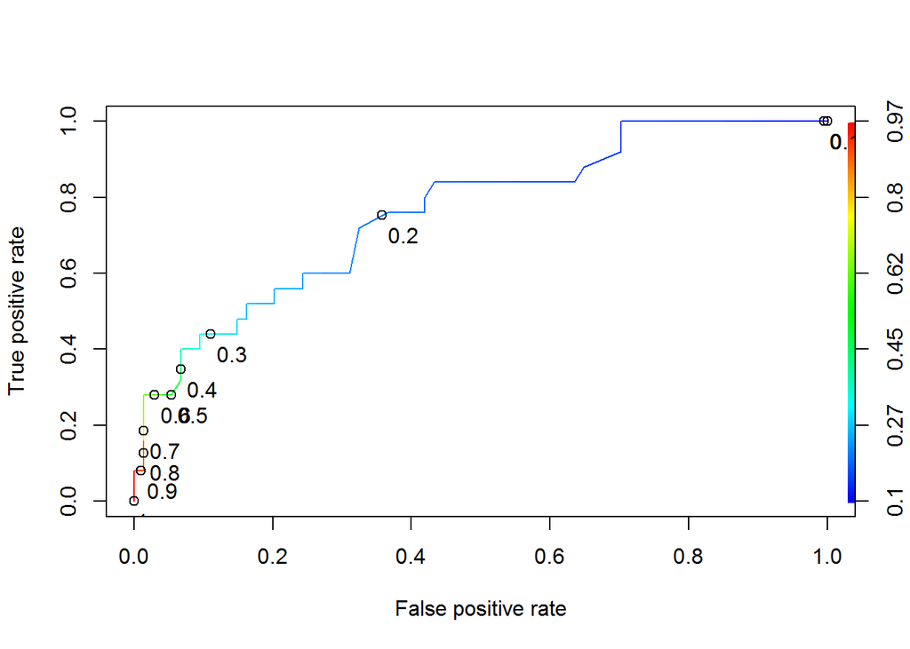

```r
ROCRpred = prediction(predictTrain, qualityTrain$PoorCare)
ROCRperf = performance(ROCRpred, "tpr", "fpr") #tpr is true positive rate and fpr is false positive rate
plot(ROCRperf, colorize=TRUE, print.cutoffs.at=seq(0,1,by=0.1), text.adj=c(-0.2,1.7))
```

```r
as.numeric(performance(ROCRpred, "auc")@y.values)
```

```
## [1] 0.7608108
```

Below we’ll illustrate how to compute lagging data. The call to stats::lag will involve passing in a Zoo Series (using the zoo library). Data is from a dataset with Influenza data. Before adding the lagged data as a column in the data frame, it has to first be converted from its Zoo series structure back to a more suitable form to be in the dataframe. Invoking the ‘coredata’ function from the ‘zoo’ package performs this conversion.

```r
FluTrain = read.csv('FluTrain.csv')
library(zoo)
ILILag2 = stats::lag(zoo(FluTrain$ILI), -2, na.pad=TRUE)
FluTrain$ILILag2 = coredata(ILILag2)
```

You’ll see above that the first two elements of FluTrain$ILILag2 are NAs. This is because there are no data points that lag the first two observations by two observations.

### This is from Analytics Edge Wk3 Recitation:2012 election prediction using model trained on 2004 and 2008 data

Load the ‘mice’ package for chained multiple imputation.

```r
library(mice)
```

Perform initial inspection of data.

```r
polling = read.csv("PollingData.csv")
str(polling)
```

```
## 'data.frame':    145 obs. of  7 variables:
##  $ State     : Factor w/ 50 levels "Alabama","Alaska",..: 1 1 2 2 3 3 3 4 4 4 ...
##  $ Year      : int  2004 2008 2004 2008 2004 2008 2012 2004 2008 2012 ...
##  $ Rasmussen : int  11 21 NA 16 5 5 8 7 10 NA ...
##  $ SurveyUSA : int  18 25 NA NA 15 NA NA 5 NA NA ...
##  $ DiffCount : int  5 5 1 6 8 9 4 8 5 2 ...
##  $ PropR     : num  1 1 1 1 1 ...
##  $ Republican: int  1 1 1 1 1 1 1 1 1 1 ...
```

```r
table(polling$Year)
```

```
##
## 2004 2008 2012
##   50   50   45
```

```r
summary(polling)
```

```
##          State          Year        Rasmussen          SurveyUSA
##  Arizona    :  3   Min.   :2004   Min.   :-41.0000   Min.   :-33.0000
##  Arkansas   :  3   1st Qu.:2004   1st Qu.: -8.0000   1st Qu.:-11.7500
##  California :  3   Median :2008   Median :  1.0000   Median : -2.0000
##  Colorado   :  3   Mean   :2008   Mean   :  0.0404   Mean   : -0.8243
##  Connecticut:  3   3rd Qu.:2012   3rd Qu.:  8.5000   3rd Qu.:  8.0000
##  Florida    :  3   Max.   :2012   Max.   : 39.0000   Max.   : 30.0000
##  (Other)    :127                  NA's   :46         NA's   :71
##    DiffCount           PropR          Republican
##  Min.   :-19.000   Min.   :0.0000   Min.   :0.0000
##  1st Qu.: -6.000   1st Qu.:0.0000   1st Qu.:0.0000
##  Median :  1.000   Median :0.6250   Median :1.0000
##  Mean   : -1.269   Mean   :0.5259   Mean   :0.5103
##  3rd Qu.:  4.000   3rd Qu.:1.0000   3rd Qu.:1.0000
##  Max.   : 11.000   Max.   :1.0000   Max.   :1.0000
##
```

Perform double imputation to fill in missing values in Rasmussen and SurveyUSA fields. To impute, we’ll include a dataset with just the 4 numeric independent variables (Rasmussen, SurveyUSA, DiffCount and PropR).

```r
simple = polling[c("Rasmussen", "SurveyUSA", "PropR", "DiffCount")]
summary(simple)
```

```
##    Rasmussen          SurveyUSA            PropR          DiffCount
##  Min.   :-41.0000   Min.   :-33.0000   Min.   :0.0000   Min.   :-19.000
##  1st Qu.: -8.0000   1st Qu.:-11.7500   1st Qu.:0.0000   1st Qu.: -6.000
##  Median :  1.0000   Median : -2.0000   Median :0.6250   Median :  1.000
##  Mean   :  0.0404   Mean   : -0.8243   Mean   :0.5259   Mean   : -1.269
##  3rd Qu.:  8.5000   3rd Qu.:  8.0000   3rd Qu.:1.0000   3rd Qu.:  4.000
##  Max.   : 39.0000   Max.   : 30.0000   Max.   :1.0000   Max.   : 11.000
##  NA's   :46         NA's   :71
```

```r
set.seed(144)
imputed = complete(mice(simple)) #mice and complete are functions from 'mice' pkg.
#After setting a seed, invoking complete() on the result of the invocation of
#mice() on a dataframe performs multiple chained imputation on that dataframe
#to handle its missing values.
summary(imputed)
```

```
##    Rasmussen         SurveyUSA           PropR          DiffCount
##  Min.   :-41.000   Min.   :-33.000   Min.   :0.0000   Min.   :-19.000
##  1st Qu.: -8.000   1st Qu.:-11.000   1st Qu.:0.0000   1st Qu.: -6.000
##  Median :  3.000   Median :  1.000   Median :0.6250   Median :  1.000
##  Mean   :  1.731   Mean   :  1.517   Mean   :0.5259   Mean   : -1.269
##  3rd Qu.: 11.000   3rd Qu.: 18.000   3rd Qu.:1.0000   3rd Qu.:  4.000
##  Max.   : 39.000   Max.   : 30.000   Max.   :1.0000   Max.   : 11.000
```

Now the Rasmussen and SurveyUSA columns in the polling dataframe will be reassigned to their imputed vectors.

```r
polling$Rasmussen = imputed$Rasmussen
polling$SurveyUSA = imputed$SurveyUSA
summary(polling)
```

```
##          State          Year        Rasmussen         SurveyUSA
##  Arizona    :  3   Min.   :2004   Min.   :-41.000   Min.   :-33.000
##  Arkansas   :  3   1st Qu.:2004   1st Qu.: -8.000   1st Qu.:-11.000
##  California :  3   Median :2008   Median :  3.000   Median :  1.000
##  Colorado   :  3   Mean   :2008   Mean   :  1.731   Mean   :  1.517
##  Connecticut:  3   3rd Qu.:2012   3rd Qu.: 11.000   3rd Qu.: 18.000
##  Florida    :  3   Max.   :2012   Max.   : 39.000   Max.   : 30.000
##  (Other)    :127
##    DiffCount           PropR          Republican
##  Min.   :-19.000   Min.   :0.0000   Min.   :0.0000
##  1st Qu.: -6.000   1st Qu.:0.0000   1st Qu.:0.0000
##  Median :  1.000   Median :0.6250   Median :1.0000
##  Mean   : -1.269   Mean   :0.5259   Mean   :0.5103
##  3rd Qu.:  4.000   3rd Qu.:1.0000   3rd Qu.:1.0000
##  Max.   : 11.000   Max.   :1.0000   Max.   :1.0000
##
```

The missing values in Rasmussen and SurveyUSA are now gone. We’ll make the training dataset hold observations from 2004 and 2008, while the test dataset will contain observations from 2012. We’ll assume that the results of the Rasmussen poll serve as a good baseline model and assess how this baseline performs on the training dataset.

```r
Train = subset(polling, Year == 2004 | Year == 2008)
Test = subset(polling, Year == 2012)
table(Train$Republican, sign(Train$Rasmussen))
```

```
##
##     -1  0  1
##   0 42  2  3
##   1  0  1 52
```

The baseline model appears to be pretty good (it only makes 3 errors and expresses ambivalence on only 3 instances).

We’ll now see if we can make a model that’ll beat this baseline model. To figure out which variables to use, we’ll first inspect the correlation matrix (taking care to include only the numeric indepent variables and the dependent variable)

```r
cor(Train[c('Rasmussen','SurveyUSA','PropR','DiffCount','Republican')])
```

```
##            Rasmussen SurveyUSA     PropR DiffCount Republican
## Rasmussen  1.0000000 0.9194508 0.8404803 0.5124098  0.8021191
## SurveyUSA  0.9194508 1.0000000 0.8756581 0.5541816  0.8205806
## PropR      0.8404803 0.8756581 1.0000000 0.8273785  0.9484204
## DiffCount  0.5124098 0.5541816 0.8273785 1.0000000  0.8092777
## Republican 0.8021191 0.8205806 0.9484204 0.8092777  1.0000000
```

PropR has the highest correlation with the dependent variable (Republican), so a judicious first attempt at a model would be one that only includes PropR.

```r
mod1=glm(Republican~PropR,data=Train,family='binomial')
summary(mod1)
```

```
##
## Call:
## glm(formula = Republican ~ PropR, family = "binomial", data = Train)
##
## Deviance Residuals:
##      Min        1Q    Median        3Q       Max
## -2.22880  -0.06541   0.10260   0.10260   1.37392
##
## Coefficients:
##             Estimate Std. Error z value Pr(>|z|)
## (Intercept)   -6.146      1.977  -3.108 0.001882 **
## PropR         11.390      3.153   3.613 0.000303 ***
## ---
## Signif. codes:  0 '***' 0.001 '**' 0.01 '*' 0.05 '.' 0.1 ' ' 1
##
## (Dispersion parameter for binomial family taken to be 1)
##
##     Null deviance: 138.269  on 99  degrees of freedom
## Residual deviance:  15.772  on 98  degrees of freedom
## AIC: 19.772
##
## Number of Fisher Scoring iterations: 8
```

```r
table(Train$Republican, predict(mod1,type='response')>=0.5)
```

```
##
##     FALSE TRUE
##   0    45    2
##   1     2   51
```

From the above, we see that the p-Value is good, the AIC is 19.772 and that the model makes 4 mistakes on the training data using a threshold of 0.5.

We’ll now see if we can do better using a two-variable model. To determine which variables to use, we’ll look for a pair of independent variables with a relatively low correlation in the correlation matrix. DiffCount and SurveyUSA seems like a good choice.

```r
mod2 = glm(Republican~SurveyUSA+DiffCount, data=Train, family="binomial")
pred2 = predict(mod2, type="response")
table(Train$Republican, pred2 >= 0.5)
```

```
##
##     FALSE TRUE
##   0    45    2
##   1     1   52
```

```r
summary(mod2)
```

```
##
## Call:
## glm(formula = Republican ~ SurveyUSA + DiffCount, family = "binomial",
##     data = Train)
##
## Deviance Residuals:
##      Min        1Q    Median        3Q       Max
## -2.01196  -0.00698   0.01005   0.05074   1.54975
##
## Coefficients:
##             Estimate Std. Error z value Pr(>|z|)
## (Intercept)  -1.1405     1.2456  -0.916   0.3599
## SurveyUSA     0.2976     0.1949   1.527   0.1267
## DiffCount     0.7673     0.4188   1.832   0.0669 .
## ---
## Signif. codes:  0 '***' 0.001 '**' 0.01 '*' 0.05 '.' 0.1 ' ' 1
##
## (Dispersion parameter for binomial family taken to be 1)
##
##     Null deviance: 138.269  on 99  degrees of freedom
## Residual deviance:  12.439  on 97  degrees of freedom
## AIC: 18.439
##
## Number of Fisher Scoring iterations: 10
```

Though this 2-independent variable model makes 3 mistakes (vs 4 using the 1-independent variable model), the p Values indicate that neither DiffCount or SurveyUSA is statistically significant with Republican in this model. On the other hand, the AIC has gone down a little to 18.439, which is favorable.

We’ll now see how the 2-independent variable model performs relative to the baseline (Rasmussen only) on the test dataset.

```r
# Smart baseline accuracy
table(Test$Republican, sign(Test$Rasmussen))
```

```
##
##     -1  0  1
##   0 18  2  4
##   1  0  0 21
```

```r
# Test set predictions
TestPrediction = predict(mod2, newdata=Test, type="response")
table(Test$Republican, TestPrediction >= 0.5)
```

```
##
##     FALSE TRUE
##   0    23    1
##   1     0   21
```

The 2-independent variable model gets only 1 wrong, while the baseline misses 4 and fails to commit on 2.

Let’s find which State the 2-independent variable model got wrong.

```r
subset(Test, !Republican & TestPrediction>=0.5)
```

```
##      State Year Rasmussen SurveyUSA DiffCount     PropR Republican
## 24 Florida 2012         2         0         6 0.6666667          0
```

It’s Florida. All numerical the independent variables indicated a close call for Florida, so this is not surprising.